# Risk Factor Analysis

## Outcome Variable

**Outcome Variable:** whz

## Predictor Variables

**Intervention Variable:** parity

**Adjustment Set:**

- arm
- W_mage
- meducyrs
- feducyrs
- hhwealth_quart
- W_mhtcm
- vagbrth
- W_nrooms
- impsan
- delta_W_mage
- delta_meducyrs
- delta_feducyrs
- delta_hhwealth_quart
- delta_W_mhtcm
- delta_vagbrth
- delta_W_nrooms
- delta_impsan

## Stratifying Variables

The analysis was stratified on these variable(s):

- agecat
- studyid
- country

## Data Summary

| agecat | studyid | country | parity | n_cell | n |
| --- | --- | --- | --- | --- | --- |
| Birth | ki1000304b-SAS-CompFeed | INDIA | 1 | 41 | 166 |
| Birth | ki1000304b-SAS-CompFeed | INDIA | 2 | 44 | 166 |
| Birth | ki1000304b-SAS-CompFeed | INDIA | 3+ | 81 | 166 |
| Birth | ki1101329-Keneba | GAMBIA | 1 | 142 | 1292 |
| Birth | ki1101329-Keneba | GAMBIA | 2 | 133 | 1292 |
| Birth | ki1101329-Keneba | GAMBIA | 3+ | 1017 | 1292 |
| Birth | ki1126311-ZVITAMBO | ZIMBABWE | 1 | 5561 | 12915 |
| Birth | ki1126311-ZVITAMBO | ZIMBABWE | 2 | 3882 | 12915 |
| Birth | ki1126311-ZVITAMBO | ZIMBABWE | 3+ | 3472 | 12915 |
| Birth | ki1135781-COHORTS | GUATEMALA | 1 | 94 | 756 |
| Birth | ki1135781-COHORTS | GUATEMALA | 2 | 118 | 756 |
| Birth | ki1135781-COHORTS | GUATEMALA | 3+ | 544 | 756 |
| Birth | ki1135781-COHORTS | INDIA | 1 | 641 | 3855 |
| Birth | ki1135781-COHORTS | INDIA | 2 | 982 | 3855 |
| Birth | ki1135781-COHORTS | INDIA | 3+ | 2232 | 3855 |
| Birth | ki1135781-COHORTS | PHILIPPINES | 1 | 640 | 2899 |
| Birth | ki1135781-COHORTS | PHILIPPINES | 2 | 657 | 2899 |
| Birth | ki1135781-COHORTS | PHILIPPINES | 3+ | 1602 | 2899 |
| Birth | kiGH5241-JiVitA-3 | BANGLADESH | 1 | 4604 | 15692 |
| Birth | kiGH5241-JiVitA-3 | BANGLADESH | 2 | 5539 | 15692 |
| Birth | kiGH5241-JiVitA-3 | BANGLADESH | 3+ | 5549 | 15692 |
| 6 months | ki1000304b-SAS-CompFeed | INDIA | 1 | 392 | 1334 |
| 6 months | ki1000304b-SAS-CompFeed | INDIA | 2 | 302 | 1334 |
| 6 months | ki1000304b-SAS-CompFeed | INDIA | 3+ | 640 | 1334 |
| 6 months | ki1000304b-SAS-FoodSuppl | INDIA | 1 | 72 | 373 |
| 6 months | ki1000304b-SAS-FoodSuppl | INDIA | 2 | 84 | 373 |
| 6 months | ki1000304b-SAS-FoodSuppl | INDIA | 3+ | 217 | 373 |
| 6 months | ki1017093b-PROVIDE | BANGLADESH | 1 | 211 | 582 |
| 6 months | ki1017093b-PROVIDE | BANGLADESH | 2 | 212 | 582 |
| 6 months | ki1017093b-PROVIDE | BANGLADESH | 3+ | 159 | 582 |

[output cut: 51 more lines]

The following strata were considered:

- agecat: 24 months, studyid: ki1017093b-PROVIDE, country: BANGLADESH
- agecat: 24 months, studyid: ki1066203-TanzaniaChild2, country: TANZANIA, UNITED REPUBLIC OF
- agecat: 24 months, studyid: ki1101329-Keneba, country: GAMBIA
- agecat: 24 months, studyid: ki1113344-GMS-Nepal, country: NEPAL
- agecat: 24 months, studyid: ki1126311-ZVITAMBO, country: ZIMBABWE
- agecat: 24 months, studyid: ki1135781-COHORTS, country: GUATEMALA
- agecat: 24 months, studyid: ki1135781-COHORTS, country: INDIA
- agecat: 24 months, studyid: ki1135781-COHORTS, country: PHILIPPINES
- agecat: 24 months, studyid: kiGH5241-JiVitA-3, country: BANGLADESH
- agecat: 6 months, studyid: ki1000304b-SAS-CompFeed, country: INDIA
- agecat: 6 months, studyid: ki1000304b-SAS-FoodSuppl, country: INDIA
- agecat: 6 months, studyid: ki1017093b-PROVIDE, country: BANGLADESH
- agecat: 6 months, studyid: ki1066203-TanzaniaChild2, country: TANZANIA, UNITED REPUBLIC OF
- agecat: 6 months, studyid: ki1101329-Keneba, country: GAMBIA
- agecat: 6 months, studyid: ki1113344-GMS-Nepal, country: NEPAL
- agecat: 6 months, studyid: ki1126311-ZVITAMBO, country: ZIMBABWE
- agecat: 6 months, studyid: ki1135781-COHORTS, country: GUATEMALA
- agecat: 6 months, studyid: ki1135781-COHORTS, country: INDIA
- agecat: 6 months, studyid: ki1135781-COHORTS, country: PHILIPPINES
- agecat: 6 months, studyid: kiGH5241-JiVitA-3, country: BANGLADESH
- agecat: Birth, studyid: ki1000304b-SAS-CompFeed, country: INDIA
- agecat: Birth, studyid: ki1101329-Keneba, country: GAMBIA
- agecat: Birth, studyid: ki1126311-ZVITAMBO, country: ZIMBABWE
- agecat: Birth, studyid: ki1135781-COHORTS, country: GUATEMALA
- agecat: Birth, studyid: ki1135781-COHORTS, country: INDIA
- agecat: Birth, studyid: ki1135781-COHORTS, country: PHILIPPINES
- agecat: Birth, studyid: kiGH5241-JiVitA-3, country: BANGLADESH

### Dropped Strata

Some strata were dropped due to rare outcomes:

- agecat: 24 months, studyid: ki1066203-TanzaniaChild2, country: TANZANIA, UNITED REPUBLIC OF

## Methods Detail

We’re interested in the causal parameters $E[Y_a]$ for all values of $a \in \mathcal{A}$. These parameters represent the mean outcome if, possibly contrary to fact, we intervened to set all units to have $A=a$. Under the randomization and positivity assumptions, these are identified by the statistical parameters $\psi_a=E_W[E_{Y|A,W}(Y|A=a,W)]$. In addition, we’re interested in the mean of $Y$, $E[Y]$ under no intervention (the observed mean). We will estimate these parameters by using SuperLearner to fit the relevant likelihood factors – $E_{Y|A,W}(Y|A=a,W)$ and $p(A=a|W)$, and then updating our likelihood fit using a joint TMLE.

For unadjusted analyses ($W=\{\}$), initial likelihoods were estimated using Lrnr_glm to estimate the simple $E(Y|A)$ and Lrnr_mean to estimate $p(A)$. For adjusted analyses, a small library containing Lrnr_glmnet, Lrnr_xgboost, and Lrnr_mean was used.

Having estimated these parameters, we will then use the delta method to estimate relative risks and attributable risks relative to a prespecified baseline level of $A$.

# Results Detail

## Results Plots

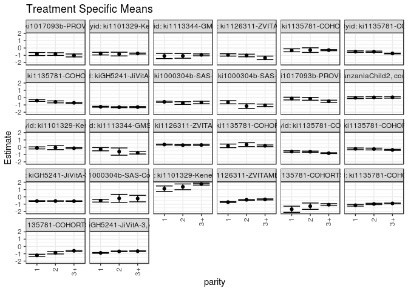

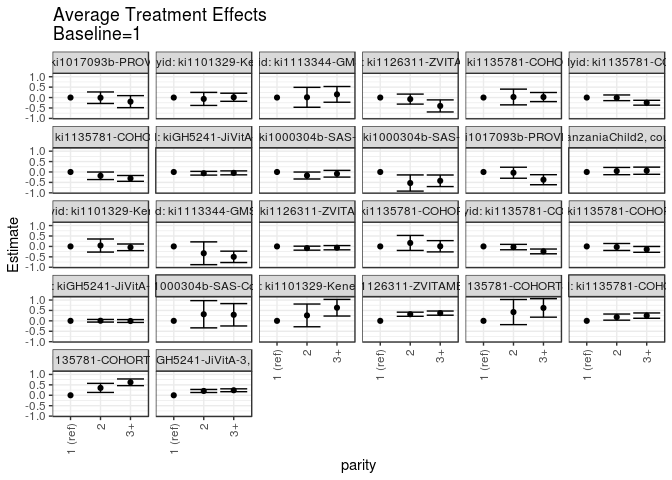

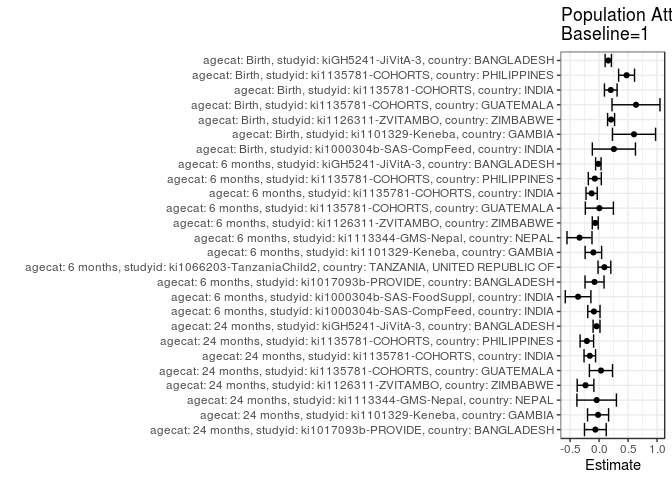

## Results Table

### Parameter: TSM

| agecat | studyid | country | intervention_level | baseline_level | estimate | ci_lower | ci_upper |
| --- | --- | --- | --- | --- | --- | --- | --- |
| Birth | ki1000304b-SAS-CompFeed | INDIA | 1 | NA | -0.5255776 | -0.7158682 | -0.3352869 |
| Birth | ki1000304b-SAS-CompFeed | INDIA | 2 | NA | -0.2089960 | -0.7523617 | 0.3343696 |
| Birth | ki1000304b-SAS-CompFeed | INDIA | 3+ | NA | -0.2349449 | -0.6802631 | 0.2103732 |
| Birth | ki1101329-Keneba | GAMBIA | 1 | NA | 1.1111190 | 0.7318197 | 1.4904184 |
| Birth | ki1101329-Keneba | GAMBIA | 2 | NA | 1.3720586 | 0.9791153 | 1.7650019 |
| Birth | ki1101329-Keneba | GAMBIA | 3+ | NA | 1.7417663 | 1.6162896 | 1.8672429 |
| Birth | ki1126311-ZVITAMBO | ZIMBABWE | 1 | NA | -0.7226499 | -0.7882084 | -0.6570914 |
| Birth | ki1126311-ZVITAMBO | ZIMBABWE | 2 | NA | -0.4052897 | -0.4795627 | -0.3310167 |
| Birth | ki1126311-ZVITAMBO | ZIMBABWE | 3+ | NA | -0.3522618 | -0.4273364 | -0.2771872 |
| Birth | ki1135781-COHORTS | GUATEMALA | 1 | NA | -1.6989558 | -2.1200676 | -1.2778440 |
| Birth | ki1135781-COHORTS | GUATEMALA | 2 | NA | -1.2779334 | -1.7119932 | -0.8438736 |
| Birth | ki1135781-COHORTS | GUATEMALA | 3+ | NA | -1.0778153 | -1.2164102 | -0.9392204 |
| Birth | ki1135781-COHORTS | INDIA | 1 | NA | -1.1516637 | -1.2661821 | -1.0371453 |
| Birth | ki1135781-COHORTS | INDIA | 2 | NA | -0.9712391 | -1.0632677 | -0.8792105 |
| Birth | ki1135781-COHORTS | INDIA | 3+ | NA | -0.9004914 | -0.9546977 | -0.8462851 |
| Birth | ki1135781-COHORTS | PHILIPPINES | 1 | NA | -1.2171807 | -1.3597573 | -1.0746042 |
| Birth | ki1135781-COHORTS | PHILIPPINES | 2 | NA | -0.8636708 | -1.0278066 | -0.6995350 |
| Birth | ki1135781-COHORTS | PHILIPPINES | 3+ | NA | -0.5950219 | -0.6675072 | -0.5225365 |
| Birth | kiGH5241-JiVitA-3 | BANGLADESH | 1 | NA | -0.8830958 | -0.9393263 | -0.8268654 |
| Birth | kiGH5241-JiVitA-3 | BANGLADESH | 2 | NA | -0.6767638 | -0.7245831 | -0.6289445 |
| Birth | kiGH5241-JiVitA-3 | BANGLADESH | 3+ | NA | -0.6421443 | -0.6840557 | -0.6002329 |
| 6 months | ki1000304b-SAS-CompFeed | INDIA | 1 | NA | -0.5769001 | -0.6620224 | -0.4917779 |
| 6 months | ki1000304b-SAS-CompFeed | INDIA | 2 | NA | -0.7470500 | -0.9321324 | -0.5619677 |
| 6 months | ki1000304b-SAS-CompFeed | INDIA | 3+ | NA | -0.6619800 | -0.8319908 | -0.4919691 |
| 6 months | ki1000304b-SAS-FoodSuppl | INDIA | 1 | NA | -0.6328484 | -0.8488050 | -0.4168917 |
| 6 months | ki1000304b-SAS-FoodSuppl | INDIA | 2 | NA | -1.1625270 | -1.4856133 | -0.8394406 |
| 6 months | ki1000304b-SAS-FoodSuppl | INDIA | 3+ | NA | -1.0550365 | -1.2285384 | -0.8815347 |
| 6 months | ki1017093b-PROVIDE | BANGLADESH | 1 | NA | -0.1302942 | -0.3166389 | 0.0560505 |
| 6 months | ki1017093b-PROVIDE | BANGLADESH | 2 | NA | -0.1659618 | -0.3528948 | 0.0209712 |
| 6 months | ki1017093b-PROVIDE | BANGLADESH | 3+ | NA | -0.5013253 | -0.6541218 | -0.3485288 |
| 6 months | ki1066203-TanzaniaChild2 | TANZANIA, UNITED REPUBLIC OF | 1 | NA | -0.0125243 | -0.1362683 | 0.1112196 |
| 6 months | ki1066203-TanzaniaChild2 | TANZANIA, UNITED REPUBLIC OF | 2 | NA | 0.0316876 | -0.0906312 | 0.1540064 |
| 6 months | ki1066203-TanzaniaChild2 | TANZANIA, UNITED REPUBLIC OF | 3+ | NA | 0.0485200 | -0.0701981 | 0.1672380 |
| 6 months | ki1101329-Keneba | GAMBIA | 1 | NA | -0.0892377 | -0.2296031 | 0.0511276 |
| 6 months | ki1101329-Keneba | GAMBIA | 2 | NA | -0.0467226 | -0.3275706 | 0.2341254 |
| 6 months | ki1101329-Keneba | GAMBIA | 3+ | NA | -0.1328208 | -0.2105102 | -0.0551314 |
| 6 months | ki1113344-GMS-Nepal | NEPAL | 1 | NA | -0.2673278 | -0.4905313 | -0.0441243 |
| 6 months | ki1113344-GMS-Nepal | NEPAL | 2 | NA | -0.5958583 | -1.0928231 | -0.0988936 |
| 6 months | ki1113344-GMS-Nepal | NEPAL | 3+ | NA | -0.7678920 | -0.9247480 | -0.6110359 |
| 6 months | ki1126311-ZVITAMBO | ZIMBABWE | 1 | NA | 0.3707513 | 0.3154358 | 0.4260669 |
| 6 months | ki1126311-ZVITAMBO | ZIMBABWE | 2 | NA | 0.2869222 | 0.2094306 | 0.3644138 |
| 6 months | ki1126311-ZVITAMBO | ZIMBABWE | 3+ | NA | 0.3087733 | 0.2227772 | 0.3947694 |
| 6 months | ki1135781-COHORTS | GUATEMALA | 1 | NA | 0.1885306 | -0.0576966 | 0.4347579 |
| 6 months | ki1135781-COHORTS | GUATEMALA | 2 | NA | 0.3550295 | 0.0895374 | 0.6205217 |
| 6 months | ki1135781-COHORTS | GUATEMALA | 3+ | NA | 0.1962224 | 0.0832053 | 0.3092394 |
| 6 months | ki1135781-COHORTS | INDIA | 1 | NA | -0.5786986 | -0.6799769 | -0.4774202 |
| 6 months | ki1135781-COHORTS | INDIA | 2 | NA | -0.6099971 | -0.6899525 | -0.5300417 |
| 6 months | ki1135781-COHORTS | INDIA | 3+ | NA | -0.8184686 | -0.8727693 | -0.7641678 |
| 6 months | ki1135781-COHORTS | PHILIPPINES | 1 | NA | -0.2204653 | -0.3372263 | -0.1037043 |
| 6 months | ki1135781-COHORTS | PHILIPPINES | 2 | NA | -0.2478699 | -0.3666155 | -0.1291243 |
| 6 months | ki1135781-COHORTS | PHILIPPINES | 3+ | NA | -0.3627062 | -0.4392945 | -0.2861178 |
| 6 months | kiGH5241-JiVitA-3 | BANGLADESH | 1 | NA | -0.5807363 | -0.6321407 | -0.5293318 |
| 6 months | kiGH5241-JiVitA-3 | BANGLADESH | 2 | NA | -0.5757730 | -0.6155276 | -0.5360184 |
| 6 months | kiGH5241-JiVitA-3 | BANGLADESH | 3+ | NA | -0.5887257 | -0.6361348 | -0.5413166 |
| 24 months | ki1017093b-PROVIDE | BANGLADESH | 1 | NA | -0.8240827 | -1.0296568 | -0.6185085 |
| 24 months | ki1017093b-PROVIDE | BANGLADESH | 2 | NA | -0.8322507 | -1.0168978 | -0.6476037 |
| 24 months | ki1017093b-PROVIDE | BANGLADESH | 3+ | NA | -1.0199392 | -1.2224279 | -0.8174505 |
| 24 months | ki1101329-Keneba | GAMBIA | 1 | NA | -0.7662821 | -0.9480315 | -0.5845327 |
| 24 months | ki1101329-Keneba | GAMBIA | 2 | NA | -0.8312850 | -1.0859939 | -0.5765762 |
| 24 months | ki1101329-Keneba | GAMBIA | 3+ | NA | -0.7516392 | -0.8209193 | -0.6823590 |
| 24 months | ki1113344-GMS-Nepal | NEPAL | 1 | NA | -1.0901942 | -1.4445289 | -0.7358595 |
| 24 months | ki1113344-GMS-Nepal | NEPAL | 2 | NA | -1.0779466 | -1.4000655 | -0.7558278 |
| 24 months | ki1113344-GMS-Nepal | NEPAL | 3+ | NA | -0.9373441 | -1.0657824 | -0.8089057 |
| 24 months | ki1126311-ZVITAMBO | ZIMBABWE | 1 | NA | -0.9469986 | -1.1070709 | -0.7869263 |
| 24 months | ki1126311-ZVITAMBO | ZIMBABWE | 2 | NA | -1.0213767 | -1.2042586 | -0.8384949 |
| 24 months | ki1126311-ZVITAMBO | ZIMBABWE | 3+ | NA | -1.3493858 | -1.5909578 | -1.1078138 |
| 24 months | ki1135781-COHORTS | GUATEMALA | 1 | NA | -0.3142520 | -0.5193858 | -0.1091182 |
| 24 months | ki1135781-COHORTS | GUATEMALA | 2 | NA | -0.2877670 | -0.6046260 | 0.0290920 |
| 24 months | ki1135781-COHORTS | GUATEMALA | 3+ | NA | -0.2895054 | -0.3652721 | -0.2137387 |
| 24 months | ki1135781-COHORTS | INDIA | 1 | NA | -0.4967900 | -0.6011339 | -0.3924461 |
| 24 months | ki1135781-COHORTS | INDIA | 2 | NA | -0.5082822 | -0.5968163 | -0.4197481 |
| 24 months | ki1135781-COHORTS | INDIA | 3+ | NA | -0.7451599 | -0.7965424 | -0.6937773 |
| 24 months | ki1135781-COHORTS | PHILIPPINES | 1 | NA | -0.3994716 | -0.5210890 | -0.2778541 |
| 24 months | ki1135781-COHORTS | PHILIPPINES | 2 | NA | -0.5827112 | -0.7161374 | -0.4492850 |
| 24 months | ki1135781-COHORTS | PHILIPPINES | 3+ | NA | -0.7073071 | -0.7761603 | -0.6384540 |
| 24 months | kiGH5241-JiVitA-3 | BANGLADESH | 1 | NA | -1.2537451 | -1.3167192 | -1.1907710 |
| 24 months | kiGH5241-JiVitA-3 | BANGLADESH | 2 | NA | -1.3136304 | -1.3785960 | -1.2486648 |
| 24 months | kiGH5241-JiVitA-3 | BANGLADESH | 3+ | NA | -1.2959898 | -1.3692885 | -1.2226912 |

### Parameter: E(Y)

| agecat | studyid | country | intervention_level | baseline_level | estimate | ci_lower | ci_upper |
| --- | --- | --- | --- | --- | --- | --- | --- |
| Birth | ki1000304b-SAS-CompFeed | INDIA | NA | NA | -0.2697590 | -0.5399211 | 0.0004030 |
| Birth | ki1101329-Keneba | GAMBIA | NA | NA | 1.7138545 | 1.6262621 | 1.8014469 |
| Birth | ki1126311-ZVITAMBO | ZIMBABWE | NA | NA | -0.5152877 | -0.5411394 | -0.4894359 |
| Birth | ki1135781-COHORTS | GUATEMALA | NA | NA | -1.0621429 | -1.1631387 | -0.9611471 |
| Birth | ki1135781-COHORTS | INDIA | NA | NA | -0.9498080 | -0.9874148 | -0.9122013 |
| Birth | ki1135781-COHORTS | PHILIPPINES | NA | NA | -0.7427251 | -0.7890855 | -0.6963647 |
| Birth | kiGH5241-JiVitA-3 | BANGLADESH | NA | NA | -0.7238886 | -0.7437224 | -0.7040548 |
| 6 months | ki1000304b-SAS-CompFeed | INDIA | NA | NA | -0.6657084 | -0.8024377 | -0.5289791 |
| 6 months | ki1000304b-SAS-FoodSuppl | INDIA | NA | NA | -0.9946381 | -1.1114079 | -0.8778682 |
| 6 months | ki1017093b-PROVIDE | BANGLADESH | NA | NA | -0.2083706 | -0.2927992 | -0.1239419 |
| 6 months | ki1066203-TanzaniaChild2 | TANZANIA, UNITED REPUBLIC OF | NA | NA | 0.0797179 | 0.0266621 | 0.1327737 |
| 6 months | ki1101329-Keneba | GAMBIA | NA | NA | -0.1874118 | -0.2456850 | -0.1291387 |
| 6 months | ki1113344-GMS-Nepal | NEPAL | NA | NA | -0.6047987 | -0.6909649 | -0.5186325 |
| 6 months | ki1126311-ZVITAMBO | ZIMBABWE | NA | NA | 0.3048076 | 0.2787350 | 0.3308802 |
| 6 months | ki1135781-COHORTS | GUATEMALA | NA | NA | 0.1940810 | 0.1226351 | 0.2655269 |
| 6 months | ki1135781-COHORTS | INDIA | NA | NA | -0.7068611 | -0.7417800 | -0.6719423 |
| 6 months | ki1135781-COHORTS | PHILIPPINES | NA | NA | -0.2938433 | -0.3352064 | -0.2524802 |
| 6 months | kiGH5241-JiVitA-3 | BANGLADESH | NA | NA | -0.5932502 | -0.6127743 | -0.5737261 |
| 24 months | ki1017093b-PROVIDE | BANGLADESH | NA | NA | -0.8879412 | -0.9708680 | -0.8050144 |
| 24 months | ki1101329-Keneba | GAMBIA | NA | NA | -0.7834078 | -0.8357743 | -0.7310414 |
| 24 months | ki1113344-GMS-Nepal | NEPAL | NA | NA | -1.1315863 | -1.2192240 | -1.0439487 |
| 24 months | ki1126311-ZVITAMBO | ZIMBABWE | NA | NA | -1.1802133 | -1.2803837 | -1.0800428 |
| 24 months | ki1135781-COHORTS | GUATEMALA | NA | NA | -0.2813755 | -0.3354674 | -0.2272835 |
| 24 months | ki1135781-COHORTS | INDIA | NA | NA | -0.6564729 | -0.6914450 | -0.6215007 |
| 24 months | ki1135781-COHORTS | PHILIPPINES | NA | NA | -0.6099592 | -0.6467541 | -0.5731643 |
| 24 months | kiGH5241-JiVitA-3 | BANGLADESH | NA | NA | -1.2971774 | -1.3204904 | -1.2738644 |

### Parameter: ATE

| agecat | studyid | country | intervention_level | baseline_level | estimate | ci_lower | ci_upper |
| --- | --- | --- | --- | --- | --- | --- | --- |
| Birth | ki1000304b-SAS-CompFeed | INDIA | 1 | 1 | 0.0000000 | 0.0000000 | 0.0000000 |
| Birth | ki1000304b-SAS-CompFeed | INDIA | 2 | 1 | 0.3165816 | -0.3368058 | 0.9699690 |
| Birth | ki1000304b-SAS-CompFeed | INDIA | 3+ | 1 | 0.2906326 | -0.2461349 | 0.8274002 |
| Birth | ki1101329-Keneba | GAMBIA | 1 | 1 | 0.0000000 | 0.0000000 | 0.0000000 |
| Birth | ki1101329-Keneba | GAMBIA | 2 | 1 | 0.2609395 | -0.2843235 | 0.8062026 |
| Birth | ki1101329-Keneba | GAMBIA | 3+ | 1 | 0.6306473 | 0.2315699 | 1.0297246 |
| Birth | ki1126311-ZVITAMBO | ZIMBABWE | 1 | 1 | 0.0000000 | 0.0000000 | 0.0000000 |
| Birth | ki1126311-ZVITAMBO | ZIMBABWE | 2 | 1 | 0.3173602 | 0.2182885 | 0.4164319 |
| Birth | ki1126311-ZVITAMBO | ZIMBABWE | 3+ | 1 | 0.3703881 | 0.2707416 | 0.4700347 |
| Birth | ki1135781-COHORTS | GUATEMALA | 1 | 1 | 0.0000000 | 0.0000000 | 0.0000000 |
| Birth | ki1135781-COHORTS | GUATEMALA | 2 | 1 | 0.4210224 | -0.1826325 | 1.0246774 |
| Birth | ki1135781-COHORTS | GUATEMALA | 3+ | 1 | 0.6211405 | 0.1775456 | 1.0647355 |
| Birth | ki1135781-COHORTS | INDIA | 1 | 1 | 0.0000000 | 0.0000000 | 0.0000000 |
| Birth | ki1135781-COHORTS | INDIA | 2 | 1 | 0.1804247 | 0.0333862 | 0.3274631 |
| Birth | ki1135781-COHORTS | INDIA | 3+ | 1 | 0.2511723 | 0.1244174 | 0.3779272 |
| Birth | ki1135781-COHORTS | PHILIPPINES | 1 | 1 | 0.0000000 | 0.0000000 | 0.0000000 |
| Birth | ki1135781-COHORTS | PHILIPPINES | 2 | 1 | 0.3535099 | 0.1360733 | 0.5709466 |
| Birth | ki1135781-COHORTS | PHILIPPINES | 3+ | 1 | 0.6221589 | 0.4620754 | 0.7822424 |
| Birth | kiGH5241-JiVitA-3 | BANGLADESH | 1 | 1 | 0.0000000 | 0.0000000 | 0.0000000 |
| Birth | kiGH5241-JiVitA-3 | BANGLADESH | 2 | 1 | 0.2063320 | 0.1332732 | 0.2793909 |
| Birth | kiGH5241-JiVitA-3 | BANGLADESH | 3+ | 1 | 0.2409515 | 0.1722458 | 0.3096573 |
| 6 months | ki1000304b-SAS-CompFeed | INDIA | 1 | 1 | 0.0000000 | 0.0000000 | 0.0000000 |
| 6 months | ki1000304b-SAS-CompFeed | INDIA | 2 | 1 | -0.1701499 | -0.3370001 | -0.0032997 |
| 6 months | ki1000304b-SAS-CompFeed | INDIA | 3+ | 1 | -0.0850798 | -0.2461597 | 0.0760000 |
| 6 months | ki1000304b-SAS-FoodSuppl | INDIA | 1 | 1 | 0.0000000 | 0.0000000 | 0.0000000 |
| 6 months | ki1000304b-SAS-FoodSuppl | INDIA | 2 | 1 | -0.5296786 | -0.9178051 | -0.1415521 |
| 6 months | ki1000304b-SAS-FoodSuppl | INDIA | 3+ | 1 | -0.4221882 | -0.6998958 | -0.1444805 |
| 6 months | ki1017093b-PROVIDE | BANGLADESH | 1 | 1 | 0.0000000 | 0.0000000 | 0.0000000 |
| 6 months | ki1017093b-PROVIDE | BANGLADESH | 2 | 1 | -0.0356676 | -0.2994701 | 0.2281349 |
| 6 months | ki1017093b-PROVIDE | BANGLADESH | 3+ | 1 | -0.3710311 | -0.6111997 | -0.1308625 |
| 6 months | ki1066203-TanzaniaChild2 | TANZANIA, UNITED REPUBLIC OF | 1 | 1 | 0.0000000 | 0.0000000 | 0.0000000 |
| 6 months | ki1066203-TanzaniaChild2 | TANZANIA, UNITED REPUBLIC OF | 2 | 1 | 0.0442119 | -0.1297356 | 0.2181595 |
| 6 months | ki1066203-TanzaniaChild2 | TANZANIA, UNITED REPUBLIC OF | 3+ | 1 | 0.0610443 | -0.1109274 | 0.2330160 |
| 6 months | ki1101329-Keneba | GAMBIA | 1 | 1 | 0.0000000 | 0.0000000 | 0.0000000 |
| 6 months | ki1101329-Keneba | GAMBIA | 2 | 1 | 0.0425151 | -0.2714862 | 0.3565164 |
| 6 months | ki1101329-Keneba | GAMBIA | 3+ | 1 | -0.0435831 | -0.2032381 | 0.1160719 |
| 6 months | ki1113344-GMS-Nepal | NEPAL | 1 | 1 | 0.0000000 | 0.0000000 | 0.0000000 |
| 6 months | ki1113344-GMS-Nepal | NEPAL | 2 | 1 | -0.3285305 | -0.8758790 | 0.2188180 |
| 6 months | ki1113344-GMS-Nepal | NEPAL | 3+ | 1 | -0.5005641 | -0.7730460 | -0.2280823 |
| 6 months | ki1126311-ZVITAMBO | ZIMBABWE | 1 | 1 | 0.0000000 | 0.0000000 | 0.0000000 |
| 6 months | ki1126311-ZVITAMBO | ZIMBABWE | 2 | 1 | -0.0838291 | -0.1791074 | 0.0114491 |
| 6 months | ki1126311-ZVITAMBO | ZIMBABWE | 3+ | 1 | -0.0619780 | -0.1642527 | 0.0402966 |
| 6 months | ki1135781-COHORTS | GUATEMALA | 1 | 1 | 0.0000000 | 0.0000000 | 0.0000000 |
| 6 months | ki1135781-COHORTS | GUATEMALA | 2 | 1 | 0.1664989 | -0.1947743 | 0.5277721 |
| 6 months | ki1135781-COHORTS | GUATEMALA | 3+ | 1 | 0.0076917 | -0.2624025 | 0.2777859 |
| 6 months | ki1135781-COHORTS | INDIA | 1 | 1 | 0.0000000 | 0.0000000 | 0.0000000 |
| 6 months | ki1135781-COHORTS | INDIA | 2 | 1 | -0.0312985 | -0.1602810 | 0.0976840 |
| 6 months | ki1135781-COHORTS | INDIA | 3+ | 1 | -0.2397700 | -0.3546582 | -0.1248818 |
| 6 months | ki1135781-COHORTS | PHILIPPINES | 1 | 1 | 0.0000000 | 0.0000000 | 0.0000000 |
| 6 months | ki1135781-COHORTS | PHILIPPINES | 2 | 1 | -0.0274046 | -0.1938747 | 0.1390655 |
| 6 months | ki1135781-COHORTS | PHILIPPINES | 3+ | 1 | -0.1422409 | -0.2818969 | -0.0025849 |
| 6 months | kiGH5241-JiVitA-3 | BANGLADESH | 1 | 1 | 0.0000000 | 0.0000000 | 0.0000000 |
| 6 months | kiGH5241-JiVitA-3 | BANGLADESH | 2 | 1 | 0.0049632 | -0.0584927 | 0.0684191 |
| 6 months | kiGH5241-JiVitA-3 | BANGLADESH | 3+ | 1 | -0.0079895 | -0.0756345 | 0.0596556 |
| 24 months | ki1017093b-PROVIDE | BANGLADESH | 1 | 1 | 0.0000000 | 0.0000000 | 0.0000000 |
| 24 months | ki1017093b-PROVIDE | BANGLADESH | 2 | 1 | -0.0081681 | -0.2839484 | 0.2676122 |
| 24 months | ki1017093b-PROVIDE | BANGLADESH | 3+ | 1 | -0.1958565 | -0.4847627 | 0.0930497 |
| 24 months | ki1101329-Keneba | GAMBIA | 1 | 1 | 0.0000000 | 0.0000000 | 0.0000000 |
| 24 months | ki1101329-Keneba | GAMBIA | 2 | 1 | -0.0650029 | -0.3780059 | 0.2480001 |
| 24 months | ki1101329-Keneba | GAMBIA | 3+ | 1 | 0.0146430 | -0.1798920 | 0.2091779 |
| 24 months | ki1113344-GMS-Nepal | NEPAL | 1 | 1 | 0.0000000 | 0.0000000 | 0.0000000 |
| 24 months | ki1113344-GMS-Nepal | NEPAL | 2 | 1 | 0.0122475 | -0.4662845 | 0.4907795 |
| 24 months | ki1113344-GMS-Nepal | NEPAL | 3+ | 1 | 0.1528501 | -0.2251763 | 0.5308766 |
| 24 months | ki1126311-ZVITAMBO | ZIMBABWE | 1 | 1 | 0.0000000 | 0.0000000 | 0.0000000 |
| 24 months | ki1126311-ZVITAMBO | ZIMBABWE | 2 | 1 | -0.0743782 | -0.3150965 | 0.1663401 |
| 24 months | ki1126311-ZVITAMBO | ZIMBABWE | 3+ | 1 | -0.4023872 | -0.6912343 | -0.1135401 |
| 24 months | ki1135781-COHORTS | GUATEMALA | 1 | 1 | 0.0000000 | 0.0000000 | 0.0000000 |
| 24 months | ki1135781-COHORTS | GUATEMALA | 2 | 1 | 0.0264850 | -0.3510507 | 0.4040207 |
| 24 months | ki1135781-COHORTS | GUATEMALA | 3+ | 1 | 0.0247466 | -0.1939336 | 0.2434269 |
| 24 months | ki1135781-COHORTS | INDIA | 1 | 1 | 0.0000000 | 0.0000000 | 0.0000000 |
| 24 months | ki1135781-COHORTS | INDIA | 2 | 1 | -0.0114922 | -0.1481753 | 0.1251909 |
| 24 months | ki1135781-COHORTS | INDIA | 3+ | 1 | -0.2483699 | -0.3646276 | -0.1321122 |
| 24 months | ki1135781-COHORTS | PHILIPPINES | 1 | 1 | 0.0000000 | 0.0000000 | 0.0000000 |
| 24 months | ki1135781-COHORTS | PHILIPPINES | 2 | 1 | -0.1832396 | -0.3635617 | -0.0029175 |
| 24 months | ki1135781-COHORTS | PHILIPPINES | 3+ | 1 | -0.3078356 | -0.4473886 | -0.1682825 |
| 24 months | kiGH5241-JiVitA-3 | BANGLADESH | 1 | 1 | 0.0000000 | 0.0000000 | 0.0000000 |
| 24 months | kiGH5241-JiVitA-3 | BANGLADESH | 2 | 1 | -0.0598853 | -0.1492091 | 0.0294384 |
| 24 months | kiGH5241-JiVitA-3 | BANGLADESH | 3+ | 1 | -0.0422448 | -0.1370175 | 0.0525279 |

### Parameter: PAR

| agecat | studyid | country | intervention_level | baseline_level | estimate | ci_lower | ci_upper |
| --- | --- | --- | --- | --- | --- | --- | --- |
| Birth | ki1000304b-SAS-CompFeed | INDIA | 1 | NA | 0.2558185 | -0.1160584 | 0.6276955 |
| Birth | ki1101329-Keneba | GAMBIA | 1 | NA | 0.6027355 | 0.2309216 | 0.9745493 |
| Birth | ki1126311-ZVITAMBO | ZIMBABWE | 1 | NA | 0.2073623 | 0.1469407 | 0.2677839 |
| Birth | ki1135781-COHORTS | GUATEMALA | 1 | NA | 0.6368130 | 0.2233680 | 1.0502579 |
| Birth | ki1135781-COHORTS | INDIA | 1 | NA | 0.2018557 | 0.0927942 | 0.3109172 |
| Birth | ki1135781-COHORTS | PHILIPPINES | 1 | NA | 0.4744556 | 0.3372866 | 0.6116247 |
| Birth | kiGH5241-JiVitA-3 | BANGLADESH | 1 | NA | 0.1592072 | 0.1047849 | 0.2136295 |
| 6 months | ki1000304b-SAS-CompFeed | INDIA | 1 | NA | -0.0888083 | -0.1943133 | 0.0166967 |
| 6 months | ki1000304b-SAS-FoodSuppl | INDIA | 1 | NA | -0.3617897 | -0.5827847 | -0.1407947 |
| 6 months | ki1017093b-PROVIDE | BANGLADESH | 1 | NA | -0.0780764 | -0.2420889 | 0.0859362 |
| 6 months | ki1066203-TanzaniaChild2 | TANZANIA, UNITED REPUBLIC OF | 1 | NA | 0.0922422 | -0.0178320 | 0.2023165 |
| 6 months | ki1101329-Keneba | GAMBIA | 1 | NA | -0.0981741 | -0.2406497 | 0.0443014 |
| 6 months | ki1113344-GMS-Nepal | NEPAL | 1 | NA | -0.3374709 | -0.5532238 | -0.1217179 |
| 6 months | ki1126311-ZVITAMBO | ZIMBABWE | 1 | NA | -0.0659438 | -0.1167847 | -0.0151029 |
| 6 months | ki1135781-COHORTS | GUATEMALA | 1 | NA | 0.0055504 | -0.2363684 | 0.2474692 |
| 6 months | ki1135781-COHORTS | INDIA | 1 | NA | -0.1281626 | -0.2248556 | -0.0314696 |
| 6 months | ki1135781-COHORTS | PHILIPPINES | 1 | NA | -0.0733780 | -0.1854350 | 0.0386789 |
| 6 months | kiGH5241-JiVitA-3 | BANGLADESH | 1 | NA | -0.0125139 | -0.0593122 | 0.0342844 |
| 24 months | ki1017093b-PROVIDE | BANGLADESH | 1 | NA | -0.0638585 | -0.2514254 | 0.1237083 |
| 24 months | ki1101329-Keneba | GAMBIA | 1 | NA | -0.0171257 | -0.1986014 | 0.1643500 |
| 24 months | ki1113344-GMS-Nepal | NEPAL | 1 | NA | -0.0413922 | -0.3820509 | 0.2992665 |
| 24 months | ki1126311-ZVITAMBO | ZIMBABWE | 1 | NA | -0.2332147 | -0.3770639 | -0.0893655 |
| 24 months | ki1135781-COHORTS | GUATEMALA | 1 | NA | 0.0328766 | -0.1666390 | 0.2323921 |
| 24 months | ki1135781-COHORTS | INDIA | 1 | NA | -0.1596829 | -0.2591807 | -0.0601850 |
| 24 months | ki1135781-COHORTS | PHILIPPINES | 1 | NA | -0.2104876 | -0.3267918 | -0.0941834 |
| 24 months | kiGH5241-JiVitA-3 | BANGLADESH | 1 | NA | -0.0434323 | -0.1029067 | 0.0160420 |